# Adult — Avaliação de Datasets para Análise Interseccional

**Objetivo:** Determinar se um dataset é viável para experimentos de justiça interseccional, identificar o melhor cruzamento de atributos sensíveis e detectar disparidades de baseline.

## Configuração do Dataset

```python
import sys, os
sys.path.insert(0, os.path.abspath(".."))

DATA_PATH = "https://archive.ics.uci.edu/ml/machine-learning-databases/adult/adult.data"

DATASET_NAME = "Adult Dataset (UCI)"

# Variável alvo binarizada (>50K será 1)
TARGET_COL       = "income"
FAVORABLE_LABEL  = 1

# Atributos sensíveis que vamos avaliar
# Nota: 'age' será convertida para 'age_group' na próxima célula
SENSITIVE_ATTRS = ["sex", "race", "age_group"]

# Subgrupos considerados estatisticamente privilegiados neste contexto
PRIVILEGED = {"sex": "Male", "race": "White"}

# Variáveis para Análises Interseccionais Secundárias (Contexto Socioeconômico)
SECONDARY_ATTRS = [
    "native-country",
    "relationship",
    "marital-status",
    "education",
    "workclass"
]

# Colunas a remover: fnlwgt (peso amostral do censo, não útil para predição direta)
DROP_COLS = ["fnlwgt"]

# Threshold: Como o dataset tem 32k linhas, 100 é um bom mínimo para estabilidade
MIN_SUBGROUP_N = 100

# ══════════════════════════════════════════════════════════════════════════════
print(f"✓ Configuração carregada para: {DATASET_NAME}")
```

```
✓ Configuração carregada para: Adult Dataset (UCI)
```

## Imports e funções auxiliares

```python
import warnings
warnings.filterwarnings("ignore")

import numpy as np
import pandas as pd
import matplotlib.colors as mcolors
import matplotlib.pyplot as plt
import matplotlib.ticker as mticker
import seaborn as sns
from matplotlib.colors import LinearSegmentedColormap
from scipy import stats
from scipy.stats import chi2_contingency

# Reordenação lógica: Do brilho para a profundidade
LAB_PALETTE_SEQUENTIAL = [
    "#f0f9fa", # Gelo (Quase branco, para correlação desprezível)
    "#b2ebf2", # Aqua suave
    "#3eccc4", # O seu Turquesa (Onde o sinal começa a aparecer)
    "#1a659e", # Azul Médio (Associação moderada)
    "#002a61"  # Marinho do Lab (O "Ponto Crítico" de associação)
]

# Configuração global do Seaborn
sns.set_theme(style="whitegrid")
sns.set_palette(LAB_PALETTE_SEQUENTIAL)

# Criando um colormap customizado para os Heatmaps baseado na paleta
LAB_CMAP = LinearSegmentedColormap.from_list("LabGradient", LAB_PALETTE_SEQUENTIAL)

# LAB_PALETTE_20 — Versão de Alta Densidade (20 Cores)
# Organizada por famílias semânticas para manter a legibilidade em gráficos complexos
LAB_PALETTE_CATEGORICAL = [
    # FAMÍLIA NAVY (Âncoras de Maior Privilégio/Status)
    "#001b3d", # Navy Ultra Escuro
    "#002a61", # Navy Original
    "#004b8d", # Navy Médio
    "#006cc2", # Navy Brilhante

    # FAMÍLIA BLUE (Grupos Intermédios Superiores)
    "#134e7a", # Blue Profundo
    "#1a659e", # Blue Original
    "#4d8fc1", # Steel Blue
    "#82b4dc", # Sky Blue Suave

    # FAMÍLIA PURPLE (Zonas de Transição e Intersecção)
    "#2e2c8f", # Deep Purple
    "#403eb1", # Purple Original
    "#6b69d6", # Medium Purple
    "#8e8cf2", # Lavender Intenso

    # FAMÍLIA TEAL/TURQUESA (Grupos de Paridade ou Novos Recortes)
    "#168275", # Deep Teal
    "#1eaf9d", # Teal Original
    "#28d1bd", # Bright Teal
    "#5fe3d3", # Mint Teal

    # FAMÍLIA AQUA/SKY (Âncoras de Maior Vulnerabilidade/Base)
    "#2fa39d", # Dark Aqua
    "#3eccc4", # Aqua Original
    "#66cbe1", # Sky Blue Original
    "#b3b1ff"  # Pale Lavender (O ponto mais claro da escala)
]

sns.set_palette(LAB_PALETTE_CATEGORICAL)

plt.rcParams.update({
    "figure.dpi": 110,
    "figure.facecolor": "white",
    "axes.spines.top": False,
    "axes.spines.right": False,
})
```

Para avaliar a disparidade de tratamento entre os subgrupos, as taxas favoráveis foram calculadas com seus respectivos Intervalos de Confiança de Wilson a 95%. Esta abordagem foi escolhida em detrimento da aproximação normal de Wald por ser estritamente limitada entre 0 e 1 e ser significativamente mais robusta e conservadora para subgrupos interseccionais com baixo número de instâncias (small $n$) ou proporções extremas de desfecho, evitando a sinalização de falsos vieses oriundos de ruído amostral.

Imagine que você está analisando o subgrupo "Mulheres Indígenas com Doutorado". Você só tem 3 mulheres nesse grupo na sua base (n = 3).

Apenas 1 delas ganha mais de 50K. A taxa observada é: 33%. Se você olhar só para os 33%, pode pensar: "Nossa, 33% delas ganham bem, a mesma taxa dos homens brancos!"

Mas se você olhar para o Intervalo de Wilson, ele vai te informar o seguinte: "Olha, a taxa observada foi 33%. Mas como você só me deu 3 pessoas para analisar, a verdadeira taxa desse grupo no mundo real pode ser qualquer coisa entre 6% e 79%."

```python
def wilson_ci(k, n, z=1.96):
    """Intervalo de confiança de Wilson para proporção. Mais robusto para n pequeno."""
    if n == 0:
        return np.nan, np.nan
    p = k / n
    denom = 1 + z**2 / n
    center = (p + z**2 / (2*n)) / denom
    spread = (z * np.sqrt(p*(1-p)/n + z**2/(4*n**2))) / denom
    return float(center - spread), float(center + spread)

def subgroup_label_stats(df, subgroup_col, target_col, favorable_label):
    """Calcula taxa favorável e IC de Wilson por subgrupo."""
    records = []
    for sg, grp in df.groupby(subgroup_col):
        n = len(grp)
        k = (grp[target_col] == favorable_label).sum()
        rate = k / n if n > 0 else np.nan
        lo, hi = wilson_ci(k, n)
        records.append({
            "subgrupo": sg, "n": n, "n_favoravel": int(k),
            "taxa_favoravel": rate, "IC_low": lo, "IC_high": hi
        })
    return pd.DataFrame(records).sort_values("subgrupo").reset_index(drop=True)

def cramers_v(df, col1, col2):
    """Cramér's V — força da associação entre dois atributos categóricos."""
    ct = pd.crosstab(df[col1], df[col2])
    chi2, _, _, _ = chi2_contingency(ct)
    n = ct.values.sum()
    k = min(ct.shape) - 1
    return float(np.sqrt(chi2 / (n * k))) if k > 0 else 0.0

print("✓ Imports e funções carregados")
```

```
✓ Imports e funções carregados
```

O intervalo de Wilson não olha apenas para a taxa observada ($p = k/n$), mas "ajusta" essa taxa com base na incerteza do tamanho da amostra (n).

A lógica segue estes passos:

- A Taxa Base ($p$): É a proporção simples (ex: 1 favorável em 10 pessoas = 0.1).
- O Ajuste de Centro: Em vez de centralizar o intervalo exatamente no 0.1, o Wilson desloca o centro levemente para cima (em direção ao 0.5). Quanto menor o n, maior esse "puxão". Isso evita que, com pouquíssimos dados, a taxa pareça "exatamente" zero ou um.
- A Variância Ajustada: O cálculo da "margem de erro" (o spread) inclui um termo de $z^2 / (4n^2)$ dentro da raiz quadrada. Esse termo garante que, mesmo se a taxa for zero, a margem de erro ainda exista e seja positiva.
- O Denominador: Tudo é dividido por $1 + z^2/n$. Isso "achata" o intervalo conforme o n diminui, impedindo que ele ultrapasse os limites de 0% ou 100%.

A justificativa para adoção é:

- Como a fórmula é baseada na inversão do teste de pontuação de Pearson, ela é matematicamente "curvada" para nunca sair do intervalo $[0, 1]$.
- No contexto interseccional, a escassez será a regra. Para $n$ pequeno, o Wald (tradicional) é excessivamente otimista (intervalos muito estreitos) ou quebra (se $k=0$, o intervalo vira 0 a 0). Wilson mantém a cobertura estatística correta mesmo com $n=1$ ou $n=2$, informando a incerteza.
- As disparidades sociais não são simétricas. Se um grupo minoritário tem taxa de 5%, a incerteza para baixo é pequena (só pode chegar a 0), mas a incerteza para cima é maior. O Wilson entende isso: Ele produz intervalos assimétricos que refletem a realidade física de que a taxa está próxima de um dos limites (0 ou 1).

## Pré-processamento

```python
# Nomes oficiais do dicionário de dados da UCI
columns = [
    "age", "workclass", "fnlwgt", "education", "education-num",
    "marital-status", "occupation", "relationship", "race", "sex",
    "capital-gain", "capital-loss", "hours-per-week", "native-country", "income"
]

# skipinitialspace=True limpa os espaços invisíveis
# na_values="?" mapeia os nulos corretamente
df_raw = pd.read_csv(DATA_PATH, names=columns, skipinitialspace=True, na_values="?")

# i) Monitoramento de Amostras (Antes da Limpeza)
shape_bruto = df_raw.shape
print(f"Shape inicial (bruto): {shape_bruto[0]:,} linhas × {shape_bruto[1]} colunas")

# Removemos colunas indesejadas antes da limpeza de nulos
if DROP_COLS:
    df_raw = df_raw.drop(columns=[c for c in DROP_COLS if c in df_raw.columns])

# Limpeza de valores nulos (registros com "?")
df = df_raw.dropna().copy()

# Monitoramento de Amostras (Depois da Limpeza)
shape_limpo = df.shape
perdidas = shape_bruto[0] - shape_limpo[0]
pct_perda = (perdidas / shape_bruto[0]) * 100

print(f"Shape após limpeza: {shape_limpo[0]:,} linhas × {shape_limpo[1]} colunas")
print(f"Amostras perdidas: {perdidas:,} ({pct_perda:.2f}% do total)")

# 1. Binarizando a variável Target
df[TARGET_COL] = df[TARGET_COL].map({'<=50K': 0, '>50K': 1})

# ii) Criando o age_group com bins específicos
# Definimos os limites (bins) e os rótulos (labels)
# O bin [0, 18, 34, 50, 65, 80, 120] cria intervalos: (0-18], (18-34], (34-50], etc.
bins = [0, 18, 34, 50, 65, 80, 120]
labels = ['0-18', '19-34', '35-50', '51-65', '66-80', '80+']
df['age_group'] = pd.cut(df['age'], bins=bins, labels=labels, right=True)

df.head(5)
```

```
Shape inicial (bruto): 32,561 linhas × 15 colunas
Shape após limpeza: 30,162 linhas × 14 colunas
Amostras perdidas: 2,399 (7.37% do total)
```

|  | age | workclass | education | education-num | marital-status | occupation | relationship | race | sex | capital-gain | capital-loss | hours-per-week | native-country | income | age_group |
| --- | --- | --- | --- | --- | --- | --- | --- | --- | --- | --- | --- | --- | --- | --- | --- |
| 0 | 39 | State-gov | Bachelors | 13 | Never-married | Adm-clerical | Not-in-family | White | Male | 2174 | 0 | 40 | United-States | 0 | 35-50 |
| 1 | 50 | Self-emp-not-inc | Bachelors | 13 | Married-civ-spouse | Exec-managerial | Husband | White | Male | 0 | 0 | 13 | United-States | 0 | 35-50 |
| 2 | 38 | Private | HS-grad | 9 | Divorced | Handlers-cleaners | Not-in-family | White | Male | 0 | 0 | 40 | United-States | 0 | 35-50 |
| 3 | 53 | Private | 11th | 7 | Married-civ-spouse | Handlers-cleaners | Husband | Black | Male | 0 | 0 | 40 | United-States | 0 | 51-65 |
| 4 | 28 | Private | Bachelors | 13 | Married-civ-spouse | Prof-specialty | Wife | Black | Female | 0 | 0 | 40 | Cuba | 0 | 19-34 |

```python
print(f"{'='*60}")
print(f"  DATASET REFINEMENT — {DATASET_NAME}")
print(f"{'='*60}\n")

df_refined = df.copy()

# 1. Race Filter: Focus on statistically dense groups
# White and Black groups provide enough samples for stable intersectional metrics.
df_refined = df_refined[df_refined['race'].isin(['White', 'Black'])]

# 2. Age Filter: Focus on prime working-age population (19-65)
# This removes outliers (minors/seniors) that skew the 'income' target.
df_refined = df_refined[df_refined['age'].between(19, 65)]

# 3. Feature Drop: Remove redundant or skewed attributes
# native-country is 91%+ US; marital-status is highly redundant with relationship.
df_refined = df_refined.drop(columns=['marital-status', 'native-country'])

# 4. Education Regrouping (Criterion: Academic Attainment Level)
edu_map = {
    'Preschool': 'Schooling', '1st-4th': 'Schooling', '5th-6th': 'Schooling',
    '7th-8th': 'Schooling', '9th': 'Schooling', '10th': 'Schooling',
    '11th': 'Schooling', '12th': 'Schooling', 'HS-grad': 'Schooling',
    'Some-college': 'Associate/College', 'Assoc-voc': 'Associate/College', 'Assoc-acdm': 'Associate/College',
    'Bachelors': 'Bachelors',
    'Masters': 'Graduate Degree', 'Prof-school': 'Graduate Degree', 'Doctorate': 'Graduate Degree'
}
df_refined['education_group'] = df_refined['education'].map(edu_map)

# 5. Workclass Regrouping (Criterion: Employment Sector)
work_map = {
    'Private': 'Private',
    'Local-gov': 'Government', 'State-gov': 'Government', 'Federal-gov': 'Government',
    'Self-emp-not-inc': 'Self-Employed', 'Self-emp-inc': 'Self-Employed',
    'Without-pay': 'Other/Unemployed', 'Never-worked': 'Other/Unemployed'
}
df_refined['workclass_group'] = df_refined['workclass'].map(work_map)

# 6. Standardization of Sensitive Labels to English
df_refined['sex'] = df_refined['sex'].replace({'Male': 'Male', 'Female': 'Female'})
# Re-categorizing Age Group with English Labels
bins = [18, 34, 50, 65]
labels = ['Young (19-34)', 'Adult (35-50)', 'Senior (51-65)']
df_refined['age_group'] = pd.cut(df_refined['age'], bins=bins, labels=labels)

# 6. Removal of statistical inconsistencies (n=1 crossover outliers that appear to be labeling errors)
df_refined = df_refined[~((df_refined['sex'] == 'Male') & (df_refined['relationship'] == 'Wife'))]
df_refined = df_refined[~((df_refined['sex'] == 'Female') & (df_refined['relationship'] == 'Husband'))]


# Update Attribute Lists
SENSITIVE_ATTRS = ["sex", "race", "age_group"]
SECONDARY_ATTRS = ["relationship", "education_group", "workclass_group"]

# Update Global DataFrame
df = df_refined.copy()

print(f"✓ Filters applied: Race (White/Black) and Age (19-65).")
print(f"✓ Features 'education' and 'workclass' regrouped and translated.")
print(f"✓ Relationship inconsistencies removed.")
print(f"Final Shape: {df.shape[0]:,} rows.")

# Saving a sample for verification
# The path follows the template's structure: ../results/figures/
FIG_PATH = "../results/figures/"
if not os.path.exists(FIG_PATH):
    os.makedirs(FIG_PATH)

print(f"✓ Figure folder ready: {FIG_PATH}")
```

```
============================================================
  DATASET REFINEMENT — Adult Dataset (UCI)
============================================================

✓ Filters applied: Race (White/Black) and Age (19-65).
✓ Features 'education' and 'workclass' regrouped and translated.
✓ Relationship inconsistencies removed.
Final Shape: 27,181 rows.
✓ Figure folder ready: ../results/figures/
```

## Bloco 1 — Inventário de Atributos Sensíveis

Distribuição marginal de cada atributo sensível (principal ou secundário) disponível.

```python
print(f"{'='*60}")
print(f"  POST-REFINEMENT INVENTORY — {DATASET_NAME}")
print(f"  Total Samples (N): {len(df):,}")
print(f"{'='*60}\n")

# Combina as listas para uma iteração completa
ALL_ANALYSIS_ATTRS = SENSITIVE_ATTRS + SECONDARY_ATTRS

for attr in ALL_ANALYSIS_ATTRS:
    print(f"  {attr} (type: {df[attr].dtype})")

    # Cálculo de frequências e proporções
    counts = df[attr].value_counts().sort_index()
    percents = df[attr].value_counts(normalize=True).sort_index() * 100

    # Exibição formatada
    for val, count in counts.items():
        pct = percents[val]
        print(f"    {str(val):<30} n={count:>6,}  ({pct:>5.1f}%)")
    print()

# Verificação de integridade de nulos
null_check = df[ALL_ANALYSIS_ATTRS].isnull().sum().sum()
if null_check == 0:
    print(f"✓ Quality Check: No missing values in analysis attributes.")
else:
    print(f"⚠ Warning: Found {null_check} missing values.")

print(f"\n{'='*60}")
```

```
============================================================
  POST-REFINEMENT INVENTORY — Adult Dataset (UCI)
  Total Samples (N): 27,181
============================================================

  sex (type: str)
    Female                         n= 8,669  ( 31.9%)
    Male                           n=18,512  ( 68.1%)

  race (type: str)
    Black                          n= 2,695  (  9.9%)
    White                          n=24,486  ( 90.1%)

  age_group (type: category)
    Young (19-34)                  n=11,472  ( 42.2%)
    Adult (35-50)                  n=11,031  ( 40.6%)
    Senior (51-65)                 n= 4,678  ( 17.2%)

  relationship (type: str)
    Husband                        n=11,510  ( 42.3%)
    Not-in-family                  n= 7,088  ( 26.1%)
    Other-relative                 n=   723  (  2.7%)
    Own-child                      n= 3,591  ( 13.2%)
    Unmarried                      n= 2,968  ( 10.9%)
    Wife                           n= 1,301  (  4.8%)

  education_group (type: str)
    Associate/College              n= 8,360  ( 30.8%)
    Bachelors                      n= 4,641  ( 17.1%)
    Graduate Degree                n= 2,281  (  8.4%)
    Schooling                      n=11,899  ( 43.8%)

  workclass_group (type: str)
    Government                     n= 3,921  ( 14.4%)
    Other/Unemployed               n=    11  (  0.0%)
    Private                        n=20,109  ( 74.0%)
    Self-Employed                  n= 3,140  ( 11.6%)

✓ Quality Check: No missing values in analysis attributes.

============================================================
```

## Bloco 2 — Viabilidade Amostral dos Subgrupos Cruzados

**1) Pré-processamento dos grupos amostrais** Objetivos:

- Redução da Variância: Eliminar subgrupos que gerariam intervalos de confiança tão largos que seriam inúteis para provar qualquer ponto.
- Controle de Variáveis de Confusão: Pessoas com menos de 18 anos ou mais de 65 têm comportamentos de renda completamente diferentes da média produtiva (estudantes ou aposentados). Mantê-los na base poderia criar "falsos positivos" de viés que, na verdade, são apenas diferenças de estágio de vida.
- Minimização da Explosão Combinatória: Agrupamento em faixas (Básico, Técnico, Graduação, Pós) mantém a hierarquia de valor da variável, mas aumenta o poder estatístico de cada grupo.
- Seleção por Relevância (Feature Selection): Ignorar native-country dada a concentração de 91,2% em um único valor. É preferível admitir que o dataset não possui diversidade geográfica suficiente do que tentar inferir padrões sobre um grupo de apenas 1 pessoa (como os vindos da Holanda).

**Resultado: Dataset aplicável**

Tabela de contingência com critério de n mínimo por subgrupo interseccional.

```
===========================================================================
  INTERSECTIONAL VIABILITY SCANNER — Adult Dataset (UCI)
===========================================================================
  Minimum Threshold (n): 100
  Total combinations tested: 12

          Intersection Pair  Subgroups  Min N Viability (%)    Verdict
                 sex × race          4   1340        100.0%     FULL ✅
            sex × age_group          6   1336        100.0%     FULL ✅
           race × age_group          6    413        100.0%     FULL ✅
         sex × relationship         12      0         83.3% PARTIAL ⚠️
      sex × education_group          8    623        100.0%     FULL ✅
      sex × workclass_group          8      4         75.0% PARTIAL ⚠️
        race × relationship         12    131        100.0%     FULL ✅
     race × education_group          8     94         87.5% PARTIAL ⚠️
     race × workclass_group          8      1         75.0% PARTIAL ⚠️
   age_group × relationship         18     60         88.9% PARTIAL ⚠️
age_group × education_group         12    462        100.0%     FULL ✅
age_group × workclass_group         12      1         75.0% PARTIAL ⚠️

✓ Analysis complete. Figure saved at: ../results/figures/Adult_Dataset_(UCI)_block2_viability_analysis.png
```

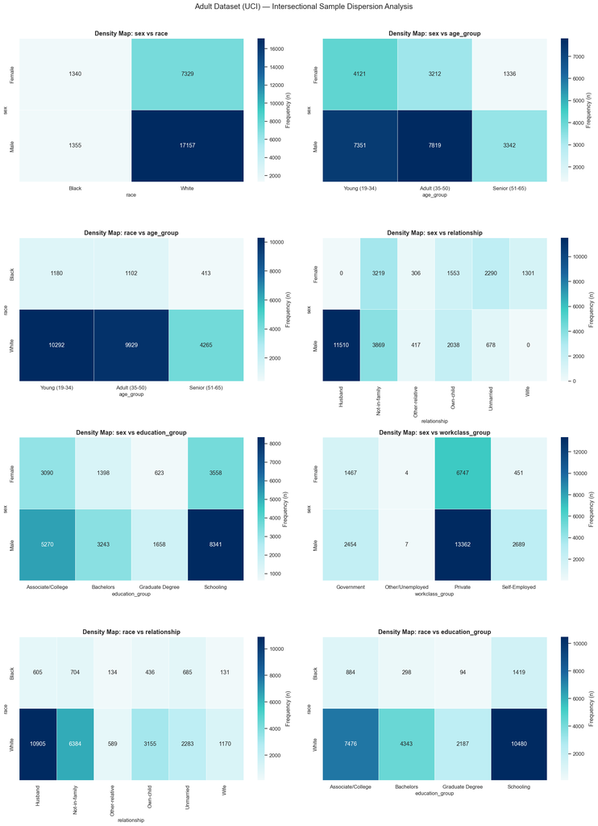

```python
import itertools
import math
import os

# ── 1. Exhaustive Pair Generation ──────────────────────────────────────────
# Identity Intersections (Sensitive x Sensitive)
sens_pairs = list(itertools.combinations(SENSITIVE_ATTRS, 2))

# Contextual Intersections (Sensitive x Secondary/Socioeconomic)
context_pairs = list(itertools.product(SENSITIVE_ATTRS, SECONDARY_ATTRS))

all_test_pairs = sens_pairs + context_pairs

print(f"{'='*75}")
print(f"  INTERSECTIONAL VIABILITY SCANNER — {DATASET_NAME}")
print(f"{'='*75}")
print(f"  Minimum Threshold (n): {MIN_SUBGROUP_N}")
print(f"  Total combinations tested: {len(all_test_pairs)}\n")

viability_records = []

# ── 2. Processing & Statistical Classification ─────────────────────────────
for attr_a, attr_b in all_test_pairs:
    # Cross-tabulation
    ct = pd.crosstab(df[attr_a], df[attr_b])

    total_subgroups = ct.size
    min_n_found = int(ct.values.min())

    # Viability Criterion: Cells meeting the threshold
    viable_cells = (ct >= MIN_SUBGROUP_N).sum().sum()
    viability_pct = (viable_cells / total_subgroups) * 100

    # Verdict Definition for Thesis Documentation
    if viability_pct == 100:
        verdict = "FULL ✅"
    elif viability_pct >= 50:
        verdict = "PARTIAL ⚠️"
    else:
        verdict = "CRITICAL ❌"

    viability_records.append({
        "Intersection Pair": f"{attr_a} × {attr_b}",
        "Subgroups": total_subgroups,
        "Min N": min_n_found,
        "Viability (%)": f"{viability_pct:.1f}%",
        "Verdict": verdict
    })

# Display Summary Table
summary_df = pd.DataFrame(viability_records)
print(summary_df.to_string(index=False))

# ── 3. Visual Analysis (Heatmaps) ──────────────────────────────────────────
# We select the most relevant pairs for the visual summary
plot_pairs = all_test_pairs[:8] # Adjust to see more/fewer plots
n_plot = len(plot_pairs)
n_cols = 2
n_rows = math.ceil(n_plot / n_cols)

fig, axes = plt.subplots(n_rows, n_cols, figsize=(18, 6 * n_rows))
axes = axes.flatten()

for i, (attr_a, attr_b) in enumerate(plot_pairs):
    ct = pd.crosstab(df[attr_a], df[attr_b])

    # Heatmap using Lab Palette and Wilson-ready annotations
    sns.heatmap(ct, annot=True, fmt="d", cmap=LAB_CMAP, ax=axes[i],
                linewidths=0.5, cbar_kws={"label": "Frequency (n)"})

    axes[i].set_title(f"Density Map: {attr_a} vs {attr_b}", fontsize=13, fontweight='bold')
    axes[i].set_xlabel(attr_b, fontsize=11)
    axes[i].set_ylabel(attr_a, fontsize=11)

# Clean empty axes
for j in range(i + 1, len(axes)):
    fig.delaxes(axes[j])

plt.suptitle(f"{DATASET_NAME} — Intersectional Sample Dispersion Analysis", fontsize=16, y=1.01)
plt.tight_layout()

# ── 4. Automatic Figure Saving ─────────────────────────────────────────────
file_name = f"{DATASET_NAME.replace(' ','_')}_block2_viability_analysis.png"
save_path = os.path.join("../results/figures/", file_name)
plt.savefig(save_path, bbox_inches="tight", dpi=300)

print(f"\n✓ Analysis complete. Figure saved at: {save_path}")
plt.show()
```

## Bloco 3 — Distribuição do Rótulo por Subgrupo

Taxa do rótulo favorável por subgrupo interseccional, com intervalo de confiança de Wilson.

```
===========================================================================
  LABEL DISTRIBUTION ANALYSIS (Income > 50K) — Adult Dataset (UCI)
===========================================================================
  Global Favorable Rate: 0.2582 (25.82%)

✓ Visualization generated and saved: sex × race
```

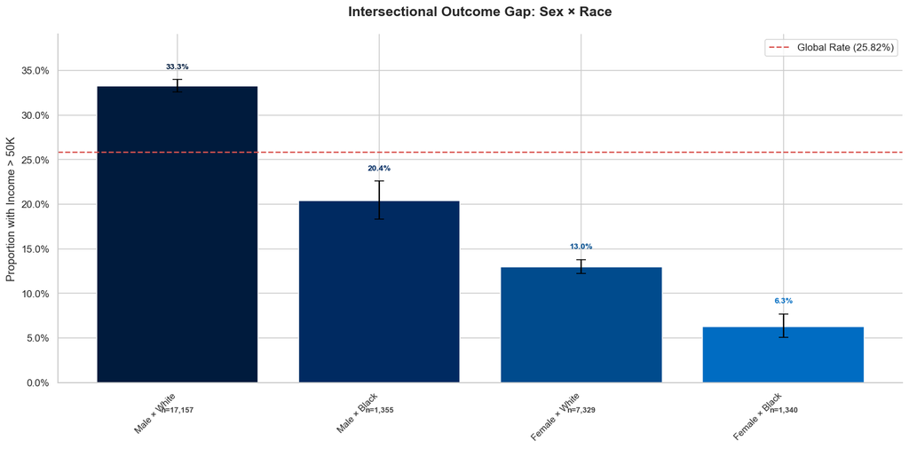

```
✓ Visualization generated and saved: sex × age_group
```

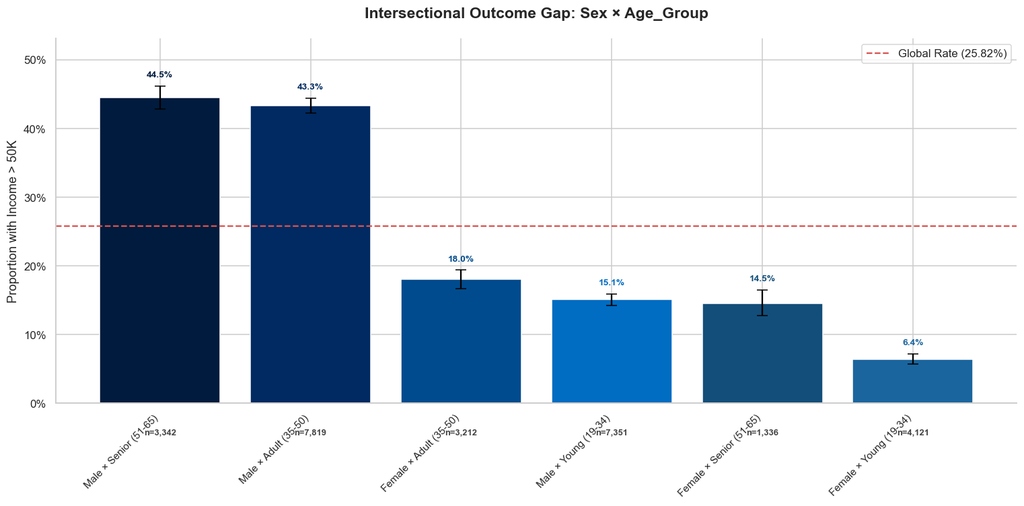

```
✓ Visualization generated and saved: race × age_group
```

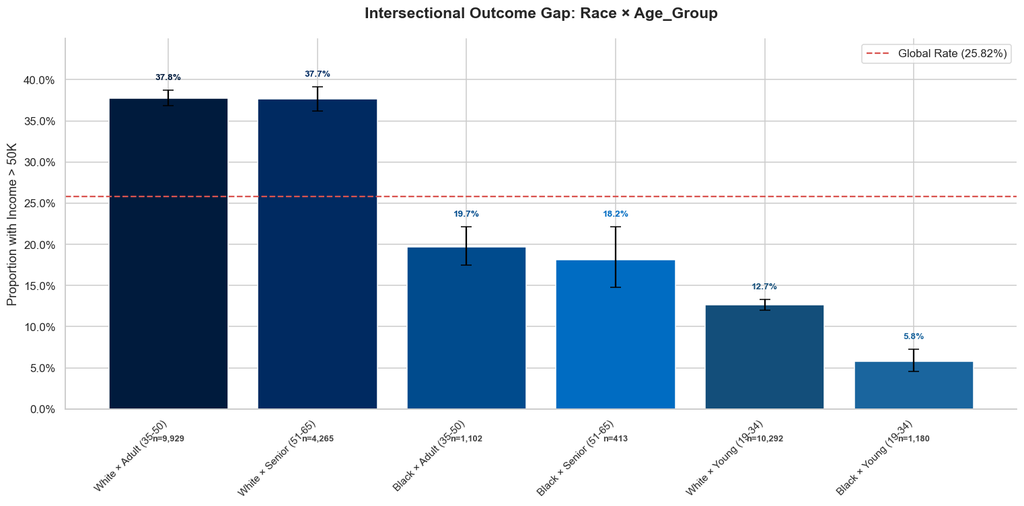

```
✓ Visualization generated and saved: sex × education_group
```

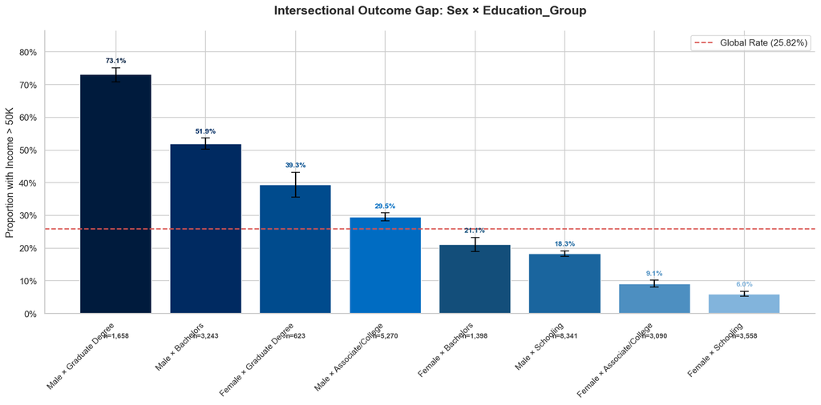

```
✓ Visualization generated and saved: sex × relationship
```

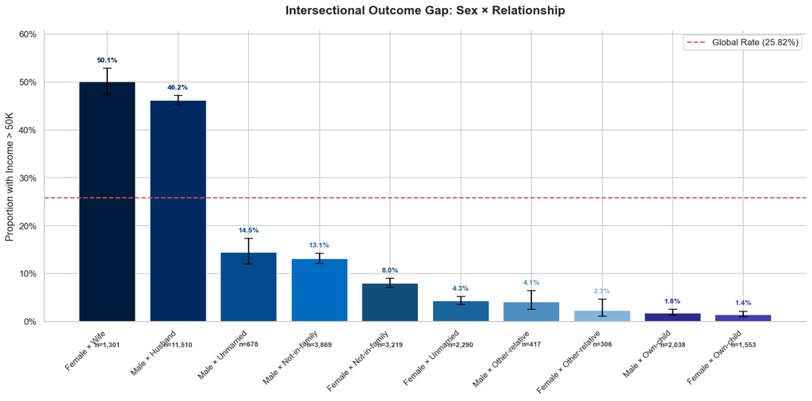

```
✓ Visualization generated and saved: race × relationship
```

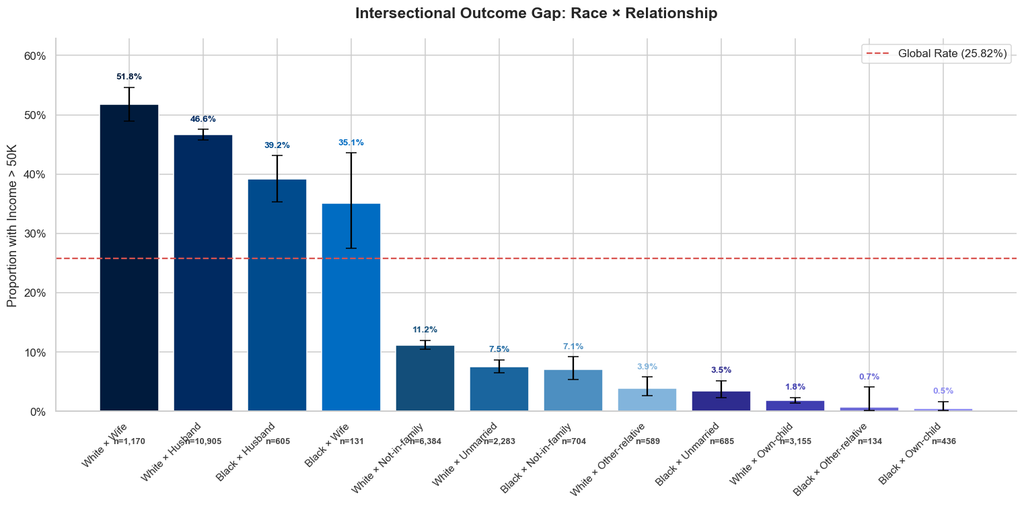

```
✓ Visualization generated and saved: age_group × education_group
```

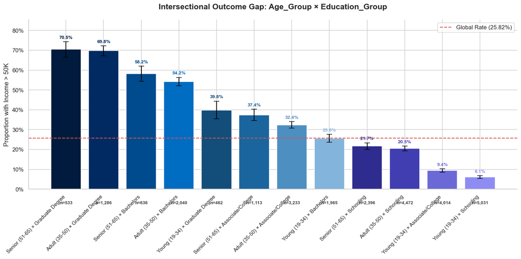

```python
# Atualizamos a lista para incluir todas as 6 que passaram com 100% no scanner
PRIMARY_INTERSECTIONS = [
    "sex × race",
    "sex × age_group",
    "race × age_group",
    "sex × education_group",
    "sex × relationship",
    "race × relationship",
    "age_group × education_group"
]

print(f"{'='*75}")
print(f"  LABEL DISTRIBUTION ANALYSIS (Income > 50K) — {DATASET_NAME}")
print(f"{'='*75}")

# Taxa global de referência (Linha Vermelha no gráfico)
global_rate = df[TARGET_COL].mean()
print(f"  Global Favorable Rate: {global_rate:.4f} ({global_rate:.2%})\n")

for intersection in PRIMARY_INTERSECTIONS:
    attrs = intersection.split(" × ")
    col_name = "_x_".join(attrs)

    # Criação dinâmica da coluna de cruzamento
    df[col_name] = df[attrs].astype(str).apply(lambda row: " × ".join(row.values), axis=1)

    # Cálculo das estatísticas com Intervalo de Wilson
    label_stats = subgroup_label_stats(df, col_name, TARGET_COL, FAVORABLE_LABEL)

    # Visualização
    fig, ax = plt.subplots(figsize=(14, 7))

    # Ordenamos pela taxa favorável para evidenciar a "Escada do Privilégio"
    label_stats = label_stats.sort_values("taxa_favoravel", ascending=False)

    x = range(len(label_stats))
    # Usando as cores do seu laboratório de forma cíclica
    palette_cycle = [LAB_PALETTE_CATEGORICAL[i % len(LAB_PALETTE_CATEGORICAL)] for i in range(len(label_stats))]

    bars = ax.bar(x, label_stats["taxa_favoravel"], color=palette_cycle, edgecolor="white", zorder=2)

    # Intervalo de Wilson (Barras de Erro)
    ax.errorbar(x, label_stats["taxa_favoravel"],
                yerr=[label_stats["taxa_favoravel"] - label_stats["IC_low"],
                      label_stats["IC_high"] - label_stats["taxa_favoravel"]],
                fmt="none", color="black", capsize=5, linewidth=1.5, zorder=3)

    # Referência Global
    ax.axhline(global_rate, color="#d9534f", linestyle="--", linewidth=1.5,
               label=f"Global Rate ({global_rate:.2%})")

    # Formatação Acadêmica em Inglês
    ax.set_xticks(x)
    ax.set_xticklabels(label_stats["subgrupo"], rotation=45, ha="right", fontsize=10)
    ax.yaxis.set_major_formatter(mticker.PercentFormatter(xmax=1))
    ax.set_title(f"Intersectional Outcome Gap: {intersection.title()}", fontsize=15, fontweight='bold', pad=20)
    ax.set_ylabel("Proportion with Income > 50K", fontsize=12)
    ax.set_ylim(0, max(label_stats["IC_high"].max(), global_rate) * 1.15)
    ax.legend(loc='upper right')

    # --- CORREÇÃO ATUALIZADA (n abaixo e % acima) ---
    for i, (idx, row) in enumerate(label_stats.iterrows()):
        # 1. Rótulo do N (abaixo do eixo X)
        ax.text(i, -0.07, f"n={int(row['n']):,}",
                ha="center", va="top",
                fontsize=8.5, fontweight='bold',
                color="#444444",
                transform=ax.get_xaxis_transform())

        # 2. Rótulo do Percentual (acima da barra de erro)
        # Usamos row['IC_high'] + um pequeno offset para não encostar na linha
        percentage = f"{row['taxa_favoravel']:.1%}"
        ax.text(i, row['IC_high'] + 0.01, percentage,
                ha='center', va='bottom',
                fontsize=9, fontweight='bold',
                color=palette_cycle[i]) # Usa a mesma cor da barra para semântica
    # ------------------------------------------------

    plt.tight_layout()

    # Salvamento automático
    fig_name = f"{DATASET_NAME.replace(' ','_')}_block3_{col_name}_distribution.png"
    save_path = os.path.join("../results/figures/", fig_name)
    plt.savefig(save_path, bbox_inches="tight", dpi=300)

    print(f"✓ Visualization generated and saved: {intersection}")
    plt.show()
```

```
===========================================================================
  PARTIAL INTERSECTION ANALYSIS (Income > 50K) — Adult Dataset (UCI)
  Note: Wilson CIs will be wider due to smaller sample sizes.
===========================================================================

✓ Visualization generated (Partial): age_group × relationship
```

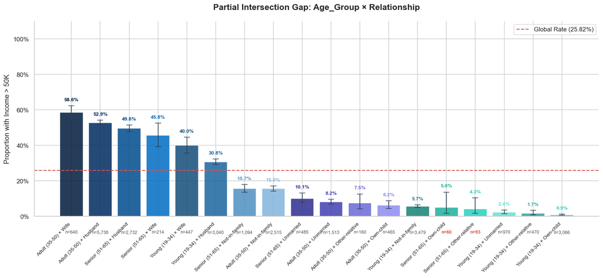

```
✓ Visualization generated (Partial): race × education_group
```

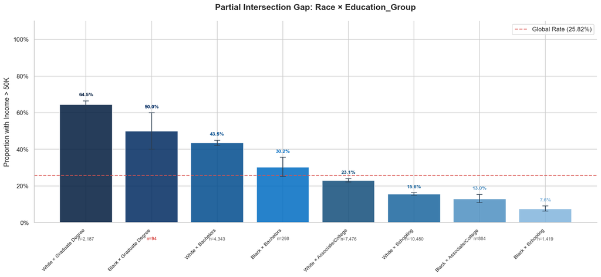

```
✓ Visualization generated (Partial): sex × workclass_group
```

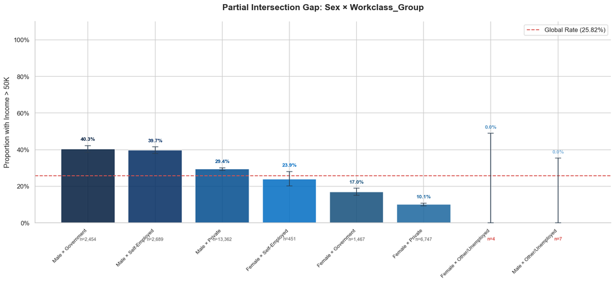

```
✓ Visualization generated (Partial): race × workclass_group
```

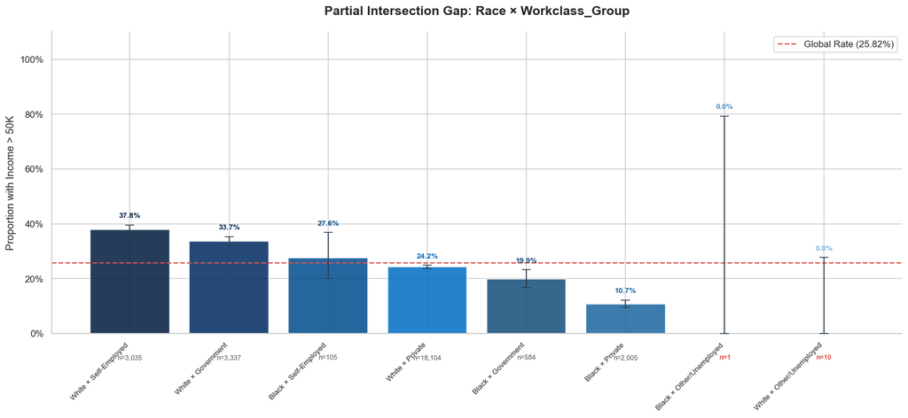

```
✓ Visualization generated (Partial): age_group × workclass_group
```

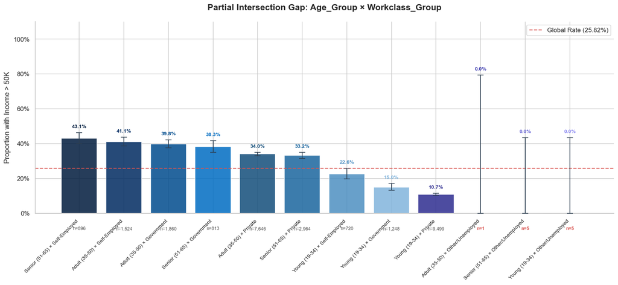

```python
# ==============================================================================
# BLOCK 3 (PART B) — OUTCOME DISTRIBUTION (PARTIAL INTERSECTIONS)
# ==============================================================================

# Lista das interseções que tiveram veredito PARTIAL no scanner
PARTIAL_INTERSECTIONS = [
    "age_group × relationship",
    "race × education_group",
    "sex × workclass_group",
    "race × workclass_group",
    "age_group × workclass_group"
]

print(f"{'='*75}")
print(f"  PARTIAL INTERSECTION ANALYSIS (Income > 50K) — {DATASET_NAME}")
print(f"  Note: Wilson CIs will be wider due to smaller sample sizes.")
print(f"{'='*75}\n")

global_rate = df[TARGET_COL].mean()

for intersection in PARTIAL_INTERSECTIONS:
    attrs = intersection.split(" × ")
    col_name = "_x_".join(attrs)

    # Criação dinâmica da coluna de cruzamento
    df[col_name] = df[attrs].astype(str).apply(lambda row: " × ".join(row.values), axis=1)

    # Cálculo das estatísticas com Intervalo de Wilson
    label_stats = subgroup_label_stats(df, col_name, TARGET_COL, FAVORABLE_LABEL)

    # Visualização
    fig, ax = plt.subplots(figsize=(15, 7))
    label_stats = label_stats.sort_values("taxa_favoravel", ascending=False)

    x = range(len(label_stats))
    palette_cycle = [LAB_PALETTE_CATEGORICAL[i % len(LAB_PALETTE_CATEGORICAL)] for i in range(len(label_stats))]

    # Plot das barras
    bars = ax.bar(x, label_stats["taxa_favoravel"], color=palette_cycle, edgecolor="white", zorder=2, alpha=0.85)

    # Intervalo de Wilson (Fundamental aqui devido ao baixo n)
    ax.errorbar(x, label_stats["taxa_favoravel"],
                yerr=[label_stats["taxa_favoravel"] - label_stats["IC_low"],
                      label_stats["IC_high"] - label_stats["taxa_favoravel"]],
                fmt="none", color="#2c3e50", capsize=5, linewidth=1.2, zorder=3)

    # Referência Global
    ax.axhline(global_rate, color="#d9534f", linestyle="--", linewidth=1.5,
               label=f"Global Rate ({global_rate:.2%})")

    # Formatação Acadêmica
    ax.set_xticks(x)
    ax.set_xticklabels(label_stats["subgrupo"], rotation=45, ha="right", fontsize=9)
    ax.yaxis.set_major_formatter(mticker.PercentFormatter(xmax=1))
    ax.set_title(f"Partial Intersection Gap: {intersection.title()}", fontsize=15, fontweight='bold', pad=20)
    ax.set_ylabel("Proportion with Income > 50K", fontsize=12)

    # Ajuste de limite para comportar as barras de erro longas
    ax.set_ylim(0, 1.1)
    ax.legend(loc='upper right')

    # --- SEÇÃO CORRIGIDA: Rótulos de n (abaixo) e % (acima) ---
    # Usamos enumerate para que 'i' seja a posição visual (0, 1, 2...)
    for i, (idx, row) in enumerate(label_stats.iterrows()):

        # 1. Rótulo do n (abaixo do eixo X) com Alerta Vermelho
        # Mantemos sua lógica de cor: vermelho se n < threshold
        n_color = "#d9534f" if row['n'] < MIN_SUBGROUP_N else "#555555"
        n_weight = 'bold' if row['n'] < MIN_SUBGROUP_N else 'normal'

        ax.text(i, -0.07, f"n={int(row['n']):,}",
                ha="center", va="top",
                fontsize=8, color=n_color, fontweight=n_weight,
                transform=ax.get_xaxis_transform())

        # 2. Rótulo do Percentual (acima da barra de erro)
        percentage = f"{row['taxa_favoravel']:.1%}"
        ax.text(i, row['IC_high'] + 0.02, percentage,
                ha='center', va='bottom',
                fontsize=9, fontweight='bold',
                color=palette_cycle[i % len(palette_cycle)])
    # ---------------------------------------------------------

    plt.tight_layout()

    # Salvamento (mantendo seu padrão de nome PARTIAL)
    fig_name = f"{DATASET_NAME.replace(' ','_')}_block3_PARTIAL_{col_name}.png"
    save_path = os.path.join("../results/figures/", fig_name)
    plt.savefig(save_path, bbox_inches="tight", dpi=300)

    print(f"✓ Visualization generated (Partial): {intersection}")
    plt.show()
```

## Bloco 4 — Gerrymandering de Justiça

Compara a disparidade observada na análise marginal (um atributo por vez) com a disparidade interseccional.

**Viés oculto positivo** = a análise marginal subestima a disparidade real.

```
=====================================================================================
  JUSTICE GERRYMANDERING AUDIT — Adult Dataset (UCI)
  Measuring the 'Hidden Bias' surplus in Intersectional Subgroups
=====================================================================================

TABLE: EVIDENCE OF INTERSECTIONAL INVISIBILITY

This table evaluates 'Hidden Bias' by contrasting the maximum marginal disparity (Expected Gap) against the real intersectional disparity (Real Gap).
A positive surplus confirms that intersectional groups face cumulative harms that remain invisible to single-axis fairness metrics.

------------------------------
GLOSSARY & INTERPRETATION:
Expected Gap: The maximum disparity found between the individual attributes that compose the pair (max[Gap_A, Gap_B]).
Real Gap: The actual difference between the most privileged and most vulnerable subgroups within the intersection.
Hidden Bias (Surplus): The 'invisible' portion of disparity. A value > 0 indicates that marginal analysis fails to see the full extent of intersectional harm.
------------------------------
```

|  | Intersection Pair | Indiv. Gap A | Indiv. Gap B | Expected Gap (Max Marginal) | Real Gap (Intersectional) | Hidden Bias (Surplus) | Audit Veredict |
| --- | --- | --- | --- | --- | --- | --- | --- |
| 0 | Sex × Race | 20.36% | 13.83% | 20.36% | 26.99% | +6.63% | ⚠️ GERRYMANDERING |
| 1 | Sex × Age_Group | 20.36% | 24.00% | 24.00% | 38.11% | +14.11% | ⚠️ GERRYMANDERING |
| 2 | Race × Age_Group | 13.83% | 24.00% | 24.00% | 32.00% | +7.99% | ⚠️ GERRYMANDERING |
| 3 | Sex × Education_Group | 20.36% | 49.23% | 49.23% | 67.09% | +17.86% | ⚠️ GERRYMANDERING |
| 4 | Sex × Relationship | 20.36% | 48.47% | 48.47% | 48.70% | +0.23% | ✅ CAPTURED |
| 5 | Race × Relationship | 13.83% | 48.47% | 48.47% | 51.34% | +2.86% | ⚠️ GERRYMANDERING |
| 6 | Age_Group × Education_Group | 24.00% | 49.23% | 49.23% | 64.42% | +15.19% | ⚠️ GERRYMANDERING |

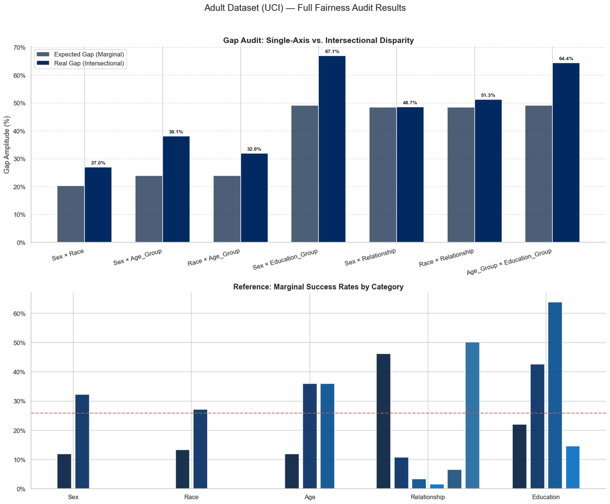

```python
print(f"{'='*85}")
print(f"  JUSTICE GERRYMANDERING AUDIT — {DATASET_NAME}")
print(f"  Measuring the 'Hidden Bias' surplus in Intersectional Subgroups")
print(f"{'='*85}\n")

# 1. Definição da lista completa de atributos para auditoria
ALL_AUDIT_ATTRS = SENSITIVE_ATTRS + SECONDARY_ATTRS

def get_marginal_gap(df, attr):
    """Calcula a amplitude de disparidade para um atributo isolado."""
    rates = df.groupby(attr)[TARGET_COL].mean()
    return float(rates.max() - rates.min()), rates

# 2. Cálculo dos Gaps Marginais (Ponto de referência tradicional)
marginal_data = {attr: get_marginal_gap(df, attr) for attr in ALL_AUDIT_ATTRS}

# 3. Auditoria de Intersecções (Pares Primários e Secundários)
audit_pairs = [
    ("sex", "race"),
    ("sex", "age_group"),
    ("race", "age_group"),
    ("sex", "education_group"),
    ("sex", "relationship"),
    ("race", "relationship"),
    ("age_group", "education_group")
]

audit_records = []

for attr_a, attr_b in audit_pairs:
    col_inter = f"{attr_a}_x_{attr_b}"
    if col_inter not in df.columns:
        df[col_inter] = df[[attr_a, attr_b]].astype(str).apply(lambda row: " × ".join(row.values), axis=1)

    # Gaps individuais (O que o auditor tradicional veria)
    gap_a = marginal_data[attr_a][0]
    gap_b = marginal_data[attr_b][0]
    max_marginal = max(gap_a, gap_b)

    # Gap interseccional (A realidade dos dados cruzados)
    stats_inter = subgroup_label_stats(df, col_inter, TARGET_COL, FAVORABLE_LABEL)
    gap_inter = float(stats_inter["taxa_favoravel"].max() - stats_inter["taxa_favoravel"].min())

    # Cálculo do Hidden Bias (O excedente de injustiça invisível)
    h_bias = gap_inter - max_marginal

    audit_records.append({
        "Intersection Pair": f"{attr_a.title()} × {attr_b.title()}",
        "Indiv. Gap A": gap_a,
        "Indiv. Gap B": gap_b,
        "Expected Gap (Max Marginal)": max_marginal,
        "Real Gap (Intersectional)": gap_inter,
        "Hidden Bias (Surplus)": h_bias,
        "Audit Veredict": "⚠️ GERRYMANDERING" if h_bias > 0.01 else "✅ CAPTURED"
    })

# --- EXIBIÇÃO DA TABELA DE EVIDÊNCIA ---
audit_df = pd.DataFrame(audit_records)
print("TABLE: EVIDENCE OF INTERSECTIONAL INVISIBILITY\n")
print("This table evaluates 'Hidden Bias' by contrasting the maximum marginal disparity (Expected Gap) against the real intersectional disparity (Real Gap).")
print("A positive surplus confirms that intersectional groups face cumulative harms that remain invisible to single-axis fairness metrics.\n")

print("-" * 30)
print("GLOSSARY & INTERPRETATION:")
# Refinado: especificando que o Expected Gap é relativo ao par da linha
print("Expected Gap: The maximum disparity found between the individual attributes that compose the pair (max[Gap_A, Gap_B]).")
print("Real Gap: The actual difference between the most privileged and most vulnerable subgroups within the intersection.")
print("Hidden Bias (Surplus): The 'invisible' portion of disparity. A value > 0 indicates that marginal analysis fails to see the full extent of intersectional harm.")
print("-" * 30)

styled_table = audit_df.style.format({
    "Indiv. Gap A": "{:.2%}", "Indiv. Gap B": "{:.2%}",
    "Expected Gap (Max Marginal)": "{:.2%}",
    "Real Gap (Intersectional)": "{:.2%}",
    "Hidden Bias (Surplus)": "{:+.2%}"
}).apply(lambda x: ['background-color: #ffcccc; font-weight: bold' if v == "⚠️ GERRYMANDERING" else '' for v in x], subset=['Audit Veredict'])

display(styled_table)

# 4. Visualização de Auditoria Global (Comparando todos os pares)
fig, axes = plt.subplots(2, 1, figsize=(15, 12))

# --- GRÁFICO A: Comparação de Gaps para Todos os Pares ---
x_audit = np.arange(len(audit_df))
width = 0.35

# Plot das barras lado a lado: Esperado vs Real
bars1 = axes[0].bar(x_audit - width/2, audit_df["Expected Gap (Max Marginal)"],
                    width, label='Expected Gap (Marginal)', color=LAB_PALETTE_CATEGORICAL[0], alpha=0.7)
bars2 = axes[0].bar(x_audit + width/2, audit_df["Real Gap (Intersectional)"],
                    width, label='Real Gap (Intersectional)', color=LAB_PALETTE_CATEGORICAL[1])

# Adicionando rótulos de percentual no topo
for bar in bars2:
    height = bar.get_height()
    axes[0].annotate(f'{height:.1%}', xy=(bar.get_x() + bar.get_width() / 2, height),
                    xytext=(0, 3), textcoords="offset points", ha='center', va='bottom', fontsize=9, fontweight='bold')

# Estilização do Gráfico A
axes[0].set_xticks(x_audit)
axes[0].set_xticklabels(audit_df["Intersection Pair"], rotation=15, ha="right")
axes[0].set_title("Gap Audit: Single-Axis vs. Intersectional Disparity", fontsize=14, fontweight='bold')
axes[0].set_ylabel("Gap Amplitude (%)")
axes[0].yaxis.set_major_formatter(mticker.PercentFormatter(xmax=1))
axes[0].legend(loc='upper left')
axes[0].grid(axis='y', linestyle='--', alpha=0.6)

# --- GRÁFICO B: Distribuição Marginal de Sucesso (Atributos Base) ---
# (Mantemos este para dar contexto aos valores individuais)
top_attrs = ["sex", "race", "age_group", "relationship", "education_group"]
x_pos = np.arange(len(top_attrs))
for i, attr in enumerate(top_attrs):
    rates = marginal_data[attr][1]
    for j, (val, rate) in enumerate(rates.items()):
        offset = (j - len(rates)/2 + 0.5) * 0.15
        axes[1].bar(i + offset, rate, width=0.12, color=LAB_PALETTE_CATEGORICAL[j % len(LAB_PALETTE_CATEGORICAL)],
                    edgecolor="white", alpha=0.9)

axes[1].axhline(global_rate, color="#d9534f", linestyle="--", alpha=0.8, label=f"Global Rate ({global_rate:.1%})")
axes[1].set_xticks(x_pos)
axes[1].set_xticklabels([a.replace('_group','').capitalize() for a in top_attrs])
axes[1].yaxis.set_major_formatter(mticker.PercentFormatter(xmax=1))
axes[1].set_title("Reference: Marginal Success Rates by Category", fontsize=13, fontweight='bold')

plt.suptitle(f"{DATASET_NAME} — Full Fairness Audit Results", fontsize=16, y=1.02)
plt.tight_layout()

# Salvamento atualizado
save_path_full = os.path.join("../results/figures/", f"{DATASET_NAME.replace(' ','_')}_block4_full_audit.png")
plt.savefig(save_path_full, bbox_inches="tight", dpi=300)
plt.show()
```

## Bloco 5 — Correlação entre Atributos Sensíveis e Features

Cramér's V entre cada atributo sensível e as variáveis preditoras categóricas.  
Correlações altas indicam possíveis variáveis proxy.

To measure the association between two categorical variables, we use Cramér's V. Unlike Pearson's correlation (which is for linear relationships between numbers), Cramér's V measures the strength of association between nominal variables on a scale from 0 to 1.

**Mathematical Formulation**

Cramér's V is derived from the Pearson's Chi-squared ($\chi^2$) test.

The calculation follows these steps:

1. Calculate the Chi-squared Statistic ($\chi^2$): We compare the observed frequencies ($O$) against the expected frequencies ($E$) under the assumption of independence.

$$\chi^2 = \sum \frac{(O_{i,j} - E_{i,j})^2}{E_{i,j}}$$

2. Compute Cramér's V: The statistic is normalized to account for the sample size ($n$) and the dimensions of the contingency table.

$$V = \sqrt{\frac{\chi^2 / n}{\min(k-1, r-1)}}$$

Where:

$n$: Total number of samples.

$k$: Number of columns in the contingency table.

$r$: Number of rows in the contingency table.

```
===========================================================================
  PROXY ANALYSIS: SENSITIVE ATTRS vs. FEATURES — Adult Dataset (UCI)
===========================================================================

  Evaluating 5 potential proxy features.

  Top Statistical Proxies (Cramér's V > 0.30 indicate strong association):
Sensitive Attribute Predictor Feature  Cramér's V
                sex      relationship    0.659258
                sex        occupation    0.440320

✓ Proxy analysis complete. Heatmap saved at: ../results/figures/Adult_Dataset_(UCI)_block5_proxy_analysis.png
```

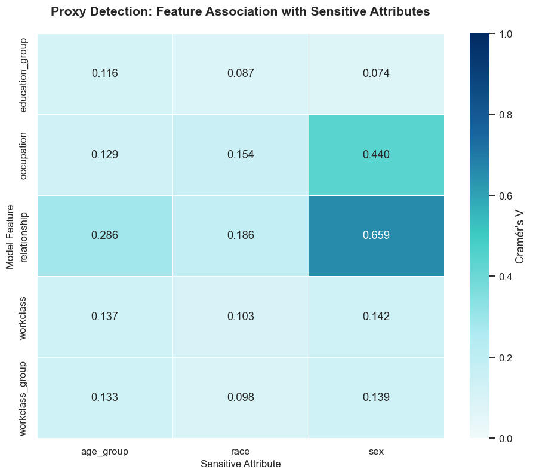

```python
print(f"{'='*75}")
print(f"  PROXY ANALYSIS: SENSITIVE ATTRS vs. FEATURES — {DATASET_NAME}")
print(f"{'='*75}\n")

# 1. Identify features to evaluate (excluding Target and temporary columns)
# Corrigido: usando 'in' para verificar substrings em nomes de colunas
feature_cols = [c for c in df.columns
                if c not in SENSITIVE_ATTRS + [TARGET_COL]
                and "_x_" not in c]

# Filter for categorical or low-cardinality features
cat_features = [c for c in feature_cols
                if df[c].dtype == "object" or df[c].dtype.name == 'category' or df[c].nunique() <= 15]

print(f"  Evaluating {len(cat_features)} potential proxy features.")

records = []
for attr in SENSITIVE_ATTRS:
    for feat in cat_features:
        try:
            # Calculate Cramér's V
            v = cramers_v(df.dropna(subset=[attr, feat]), attr, feat)
            records.append({
                "Sensitive Attribute": attr,
                "Predictor Feature": feat,
                "Cramér's V": v
            })
        except Exception as e:
            continue

cv_df = pd.DataFrame(records)

# 2. Top Proxies Summary
print("\n  Top Statistical Proxies (Cramér's V > 0.30 indicate strong association):")
if not cv_df.empty:
    high_proxies = cv_df[cv_df["Cramér's V"] > 0.30].sort_values("Cramér's V", ascending=False)
    if not high_proxies.empty:
        print(high_proxies.to_string(index=False))
    else:
        print("  No strong proxies detected (V > 0.30).")
else:
    print("  No data recorded for proxies.")

# 3. Visualization: Correlation Heatmap
if not cv_df.empty:
    pivot_cv = cv_df.pivot(index="Predictor Feature", columns="Sensitive Attribute", values="Cramér's V")

    plt.figure(figsize=(10, 8))
    sns.heatmap(pivot_cv, annot=True, fmt=".3f", cmap=LAB_CMAP,
                vmin=0, vmax=1, linewidths=0.5, cbar_kws={"label": "Cramér's V"})

    plt.title(f"Proxy Detection: Feature Association with Sensitive Attributes", fontsize=14, fontweight='bold', pad=20)
    plt.xlabel("Sensitive Attribute", fontsize=11)
    plt.ylabel("Model Feature", fontsize=11)

    # 4. Save Figure
    save_path = os.path.join("../results/figures/", f"{DATASET_NAME.replace(' ','_')}_block5_proxy_analysis.png")
    plt.savefig(save_path, bbox_inches="tight", dpi=300)

    print(f"\n✓ Proxy analysis complete. Heatmap saved at: {save_path}")
    plt.show()
```

## Bloco 6 — DATA-DRIVEN INTERSECTIONAL RANKING

The ranking system establishes optimization priority through a Priority Score, allowing the dataset to reveal where bias is most severe without subjective researcher interference.

$$\text{Priority Score} = (\text{Hidden Bias} \times 0.7) + (\text{Real Gap} \times 0.3)$$

Calculation Criteria:

- Hidden Bias (70% Weight): The primary metric. It identifies the Justice Gerrymandering phenomenon, prioritizing intersections where bias is "invisible" to traditional (single-axis) metrics.
- Real Gap (30% Weight): Evaluates the absolute severity of exclusion by measuring the total distance between the most and least privileged subgroups.
- Viability Filter (Hard Constraint): Before scoring, the system validates whether all subgroups meet the minimum sample size ($n$). Inviable intersections are discarded or moved to the bottom of the ranking to prevent statistically unstable conclusions.

```python
# 1. Padronização das chaves para o merge seguro (Resolve Case-Sensitivity)
audit_df['Merge_Key'] = audit_df['Intersection Pair'].str.lower().str.replace(" ", "")
summary_df['Merge_Key'] = summary_df['Intersection Pair'].str.lower().str.replace(" ", "")

# 2. Consolidação de Dados
decision_matrix = pd.merge(
    audit_df,
    summary_df[['Merge_Key', 'Min N']],
    on='Merge_Key'
).drop(columns=['Merge_Key'])

# 3. Definição do Score de Prioridade Objetiva
decision_matrix['Priority_Score'] = (
    (decision_matrix['Hidden Bias (Surplus)'] * 0.7) +
    (decision_matrix['Real Gap (Intersectional)'] * 0.3)
)

# Filtro de Viabilidade (Hard Constraint)
decision_matrix['Is_Viable'] = decision_matrix['Min N'] >= MIN_SUBGROUP_N

# 4. Ranquear as intersecções
ranked_audit = decision_matrix.sort_values(by=['Is_Viable', 'Priority_Score'], ascending=False)

# ── EXIBIÇÃO DO RANKING GLOBAL ───────────────────────────────────────────────
print(f"{'═'*85}")
print(f"  GLOBAL INTERSECTIONAL AUDIT — {DATASET_NAME}")
print(f"  Ranking candidates for Fairness Optimization based on Objective Criteria")
print(f"{'═'*85}\n")

def highlight_viability(val):
    color = 'lightgreen' if val >= MIN_SUBGROUP_N else '#ffcccc'
    return f'background-color: {color}'

display(ranked_audit.style.format({
    "Indiv. Gap A": "{:.2%}", "Indiv. Gap B": "{:.2%}",
    "Expected Gap (Max Marginal)": "{:.2%}", "Real Gap (Intersectional)": "{:.2%}",
    "Hidden Bias (Surplus)": "{:+.2%}", "Priority_Score": "{:.4f}"
}).map(highlight_viability, subset=['Min N']))

# ── 5. VEREDITO DO "MELHOR CANDIDATO" ─────────────────────────────────────────
viable_candidates = ranked_audit[ranked_audit['Is_Viable']]

if not viable_candidates.empty:
    best_candidate = viable_candidates.iloc[0]
    print(f"\n🏆 PRIMARY CANDIDATE FOR OPTIMIZATION: {best_candidate['Intersection Pair']}")
    print(f"  - This pair shows the highest combination of 'Hidden Bias' and total disparity.")
    print(f"  - All subgroups meet the minimum density (Min N = {best_candidate['Min N']}).")
else:
    print("\n❌ NO VIABLE CANDIDATES FOUND")
    print(f"  - All intersection pairs have subgroups with N < {MIN_SUBGROUP_N}.")
    print("  - Consider reducing MIN_SUBGROUP_N or reviewing your data filters.")

# ── 6. NOTAS DE PROXY (Integração com Bloco 5) ────────────────────────────────
try:
    top_proxies = cv_df[cv_df["Cramér's V"] > 0.30].sort_values("Cramér's V", ascending=False)
    if not top_proxies.empty:
        print(f"\n⚠️ PROXY RISK DETECTED:")
        for _, row in top_proxies.head(2).iterrows():
            print(f"  - '{row['Predictor Feature']}' leaks information about '{row['Sensitive Attribute']}' (V={row['Cramér\'s V']:.3f})")
except:
    pass

print(f"\n{'═'*85}")
```

```
═════════════════════════════════════════════════════════════════════════════════════
  GLOBAL INTERSECTIONAL AUDIT — Adult Dataset (UCI)
  Ranking candidates for Fairness Optimization based on Objective Criteria
═════════════════════════════════════════════════════════════════════════════════════
```

|  | Intersection Pair | Indiv. Gap A | Indiv. Gap B | Expected Gap (Max Marginal) | Real Gap (Intersectional) | Hidden Bias (Surplus) | Audit Veredict | Min N | Priority_Score | Is_Viable |
| --- | --- | --- | --- | --- | --- | --- | --- | --- | --- | --- |
| 3 | Sex × Education_Group | 20.36% | 49.23% | 49.23% | 67.09% | +17.86% | ⚠️ GERRYMANDERING | 623 | 0.3263 | True |
| 6 | Age_Group × Education_Group | 24.00% | 49.23% | 49.23% | 64.42% | +15.19% | ⚠️ GERRYMANDERING | 462 | 0.2996 | True |
| 1 | Sex × Age_Group | 20.36% | 24.00% | 24.00% | 38.11% | +14.11% | ⚠️ GERRYMANDERING | 1336 | 0.2131 | True |
| 5 | Race × Relationship | 13.83% | 48.47% | 48.47% | 51.34% | +2.86% | ⚠️ GERRYMANDERING | 131 | 0.1741 | True |
| 2 | Race × Age_Group | 13.83% | 24.00% | 24.00% | 32.00% | +7.99% | ⚠️ GERRYMANDERING | 413 | 0.1519 | True |
| 0 | Sex × Race | 20.36% | 13.83% | 20.36% | 26.99% | +6.63% | ⚠️ GERRYMANDERING | 1340 | 0.1273 | True |
| 4 | Sex × Relationship | 20.36% | 48.47% | 48.47% | 48.70% | +0.23% | ✅ CAPTURED | 0 | 0.1477 | False |

```
🏆 PRIMARY CANDIDATE FOR OPTIMIZATION: Sex × Education_Group
  - This pair shows the highest combination of 'Hidden Bias' and total disparity.
  - All subgroups meet the minimum density (Min N = 623).

⚠️ PROXY RISK DETECTED:
  - 'relationship' leaks information about 'sex' (V=0.659)
  - 'occupation' leaks information about 'sex' (V=0.440)

═════════════════════════════════════════════════════════════════════════════════════
```

## Bloco 7 — Sanity Check

```python
print("🔍 Executando validação final do dataset...")

# 1. Verifica se o dataset não foi acidentalmente esvaziado pelos filtros
assert len(df) > 0, "Erro crítico: O dataset ficou vazio após o refinamento!"

# 2. Verifica ausência de dados nulos nas colunas estruturais
cols_to_check = SENSITIVE_ATTRS + [TARGET_COL]
assert df[cols_to_check].isnull().sum().sum() == 0, f"Erro: Valores nulos detectados nas colunas cruciais {cols_to_check}!"

# 3. Validação do Target (Garante que a variável alvo é estritamente binária)
assert df[TARGET_COL].nunique() == 2, f"Erro: A variável alvo '{TARGET_COL}' não possui exatamente 2 classes!"

print(f"✅ Todos os checks genéricos de integridade passaram.")
print(f"📊 Dataset finalizado com {len(df):,} amostras e pronto para a etapa de otimização.")
```

```
🔍 Executando validação final do dataset...
✅ Todos os checks genéricos de integridade passaram.
📊 Dataset finalizado com 27,181 amostras e pronto para a etapa de otimização.
```

## Bloco 8 — PRE-TRAINING INTERSECTIONAL BIAS EVALUATION (TABLE 1 ADAPTATION)

The Class Imbalance Ratio (CI Ratio) measures the overall proportion between the majority and minority classes of the target variable, highlighting the general data distribution. Conversely, the Intersectional Disparate Impact (DI Pre-train) focuses on fairness assessment; it is calculated by dividing the favorable outcome rate of the most unprivileged subgroup by the rate of the most privileged subgroup within a specific intersection (such as sex and education). In the fairness literature, DI values below 0.80 violate the "Four-Fifths Rule," statistically proving that the historical baseline data carries severe discriminatory bias and necessitates multiobjective mitigation.

```python
print("Calculando Métricas de Viés Pré-Treino Interseccional...\n")

# 1. Estatísticas Globais do Dataset
N_total = len(df)
class_counts = df[TARGET_COL].value_counts(normalize=True) * 100
maj_class = class_counts.max()
min_class = class_counts.min()

ci_ratio = maj_class / min_class
class_dist_str = f"{maj_class:.1f} / {min_class:.1f}"

# --- NOVO: Exibição das métricas globais como cabeçalho ---
print(f"📊 DATASET OVERVIEW: {DATASET_NAME}")
print(f"   Target Attribute : {TARGET_COL}")
print(f"   Total Instances  : {N_total:,}")
print(f"   Class Dist (%)   : {class_dist_str}")
print(f"   CI Ratio         : {ci_ratio:.2f}")
print("-" * 55)

# 2. Definir as intersecções para o relatório
intersections_to_report = [
    "sex_x_education_group",
    "age_group_x_education_group",
    "sex_x_age_group",
    "race_x_relationship",
    "race_x_age_group",
    "sex_x_race",
    "sex_x_relationship"
]

records = []

# 3. Loop de Cálculo do Intersectional DI
for inter in intersections_to_report:
    if inter in df.columns:
        subgroup_rates = df.groupby(inter)[TARGET_COL].apply(lambda x: (x == FAVORABLE_LABEL).mean())

        max_rate = subgroup_rates.max()
        min_rate = subgroup_rates.min()

        priv_group = subgroup_rates.idxmax()
        unpriv_group = subgroup_rates.idxmin()

        di_pre_train = min_rate / max_rate if max_rate > 0 else 0.0

        records.append({
            "Intersection Pair": inter.replace("_", " ").title(),
            "Most Privileged": priv_group,
            "Most Unprivileged": unpriv_group,
            "DI Pre-train": round(di_pre_train, 2)
        })

# 4. Formatação e Exibição da Tabela Enxuta
pre_train_bias_table = pd.DataFrame(records)

print(f"\n{'='*80}")
print(" Table 1. Intersectional Pre-training Bias Evaluation.")
print(f"{'='*80}")

def highlight_di(val):
    if isinstance(val, float) and val < 0.80:
        return 'color: #d9534f; font-weight: bold'
    return ''

display(pre_train_bias_table.style.format({
    "DI Pre-train": "{:.2f}"
}).map(highlight_di, subset=['DI Pre-train']).hide(axis='index'))
```

```
Calculando Métricas de Viés Pré-Treino Interseccional...

📊 DATASET OVERVIEW: Adult Dataset (UCI)
   Target Attribute : income
   Total Instances  : 27,181
   Class Dist (%)   : 74.2 / 25.8
   CI Ratio         : 2.87
-------------------------------------------------------

================================================================================
 Table 1. Intersectional Pre-training Bias Evaluation.
================================================================================
```

| Intersection Pair | Most Privileged | Most Unprivileged | DI Pre-train |
| --- | --- | --- | --- |
| Sex X Education Group | Male × Graduate Degree | Female × Schooling | 0.08 |
| Age Group X Education Group | Senior (51-65) × Graduate Degree | Young (19-34) × Schooling | 0.09 |
| Sex X Age Group | Male × Senior (51-65) | Female × Young (19-34) | 0.14 |
| Race X Relationship | White × Wife | Black × Own-child | 0.01 |
| Race X Age Group | White × Adult (35-50) | Black × Young (19-34) | 0.15 |
| Sex X Race | Male × White | Female × Black | 0.19 |
| Sex X Relationship | Female × Wife | Female × Own-child | 0.03 |